# PV Installations and Electricity Price Analysis in Switzerland

1. Introduction
2. Exploratory Data Analysis
3. Simulations
4. Groupe E Simulation
5. Predictions
6. OFEN Predictions
7. Conclusion

## Introduction

The growing adoption of PV installations in Switzerland presents both opportunities and challenges for energy stakeholders. This report explores historical data on PV installations and electricity prices, uncovering patterns and trends that form the foundation for further analysis. Using this data, we simulate and evaluate the potential profitability of leveraging an energy storage system.

## Exploratory Data Analysis

```python
import pandas as pd
import numpy as np
import matplotlib.pyplot as plt
import seaborn as sns

from statsmodels.tsa.stattools import adfuller
from sklearn.model_selection import train_test_split, cross_val_score
from sklearn.ensemble import RandomForestRegressor, GradientBoostingRegressor
from sklearn.linear_model import LinearRegression, Ridge
from sklearn.svm import SVR
from sklearn.metrics import mean_absolute_error, mean_squared_error
from statsmodels.tsa.arima.model import ARIMA
from sklearn.preprocessing import PolynomialFeatures
from sklearn.metrics import r2_score
```

```python
# Loading data
pv_data = pd.read_excel("new_PVs.xlsx")
price_data = pd.read_csv("prices.csv")
production_data = pd.read_excel("PV_production.xlsx")
```

```python
# Checking for missing data
missing_pv = pv_data.isnull().sum()
print(missing_pv)

missing_price = price_data.isnull().sum()
print(missing_price)

missing_production = production_data.isnull().sum()
print(missing_production)
```

```
Year                         0
New_PVs_MWp                  0
Installed Capacity Growth    1
dtype: int64
Date (GMT+1)              0
Day Ahead Auction (CH)    0
dtype: int64
Year                        0
PV Production (GWh)         0
Annual Production Growth    1
dtype: int64
```

There is one missing value in Installed Capacity Growth and Annual Production Growth columns respectively as there is no growth rate in the first year. We will ignore them as these are not used in this analysis.

```python
# Cleaning data
price_data['Date'] = pd.to_datetime(price_data['Date (GMT+1)'], format="%d.%m.%Y %H:%M")
price_data['Year'] = price_data['Date'].dt.year
price_data['Day Ahead Auction (CH)'] = pd.to_numeric(price_data['Day Ahead Auction (CH)'])
```

### Has the number of imbalances (negative prices) been increasing?

Yes, the number of imbalances has been increasing, with a sharp rise observed in 2024. However, the year 2022 does not seem to follow this upward trend. An explanation will be provided in a later section.

```python
# Counting negative price occurrences per year
negative_price_count = price_data[price_data['Day Ahead Auction (CH)'] < 0].groupby('Year').size()
```

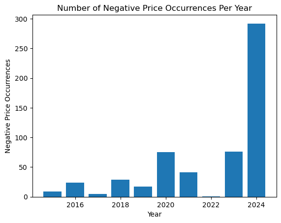

```python
# Plotting the number of negative price occurences per year
plt.bar(negative_price_count.index, negative_price_count.values)
plt.title('Number of Negative Price Occurrences Per Year')
plt.xlabel('Year')
plt.ylabel('Negative Price Occurrences')
plt.show()
```

### Is there any relationship between the number of PV installations and negative price occurrences?

There is a strong positive relationship between these variables as the increased production of solar energy can lead to an oversupply in the market, resulting in negative prices.

```python
# Joining dataframes
pv_price_count = pv_data.merge(negative_price_count.rename('Negative_Prices'), on='Year', how='inner')
# Removing 2022 as it is considered as an outliner
pv_price_count_without_2022 = pv_price_count[pv_price_count['Year'] != 2022]
```

```python
# Calculating the correlation coefficient
correlation = pv_price_count_without_2022['New_PVs_MWp'].corr(pv_price_count_without_2022['Negative_Prices'])
print(f"Correlation coefficient: {correlation}")
```

```
Correlation coefficient: 0.7998856363031667
```

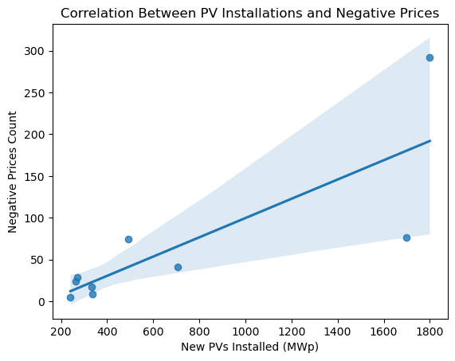

```python
# Plotting with trend line
sns.regplot(x='New_PVs_MWp', y='Negative_Prices', data=pv_price_count_without_2022)
plt.title('Correlation Between PV Installations and Negative Prices')
plt.xlabel('New PVs Installed (MWp)')
plt.ylabel('Negative Prices Count')
plt.show()
```

### How many days per year negative price occurrences happen?

```python
# Extracting only the rows with negative prices
negative_price_data = price_data[price_data['Day Ahead Auction (CH)'] < 0].copy()
# Creating a 'Date_only' column containing just the date (no time)
negative_price_data['Date_only'] = negative_price_data['Date'].dt.date
# Grouping by day
negative_price_daily_count = negative_price_data.groupby('Date_only').size()
print(negative_price_daily_count)
```

```
Date_only
2015-05-10     5
2015-05-17     4
2016-03-28     4
2016-05-08     6
2016-05-15    12
              ..
2024-09-29     2
2024-10-06     2
2024-10-13     9
2024-10-20     3
2024-10-21     2
Length: 120, dtype: int64
```

```python
# Extracting year from the 'Date_only' column
negative_price_data['Year'] = pd.to_datetime(negative_price_data['Date_only']).dt.year
# Counting unique days with negative prices per year
negative_price_days = negative_price_data.groupby('Year')['Date_only'].nunique().reset_index(name='Negative_Price_Days')
print(negative_price_days)
```

```
   Year  Negative_Price_Days
0  2015                    2
1  2016                    5
2  2017                    1
3  2018                    4
4  2019                    6
5  2020                   15
6  2021                    8
7  2022                    1
8  2023                   18
9  2024                   60
```

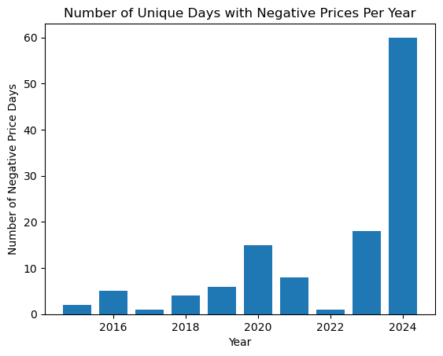

```python
# Plotting
plt.bar(negative_price_days['Year'], negative_price_days['Negative_Price_Days'])
plt.title('Number of Unique Days with Negative Prices Per Year')
plt.xlabel('Year')
plt.ylabel('Number of Negative Price Days')
plt.show()
```

```python
# Joining dataframes
pv_price_days = pv_price_count.merge(negative_price_days, on='Year', how='inner')
# Removing 2022 as it is considered as an outliner
pv_price_days_without_2022 = pv_price_days[pv_price_days['Year'] != 2022]
```

### Is the number of days with negative prices associated with PV installations?

Yes, the number of days with negative prices is positively associated with the number of PV installations, revealing a even stronger correlation coefficient of 0.82.

```python
# Calculating the correlation coefficient
correlation_pv_price_days = pv_price_days_without_2022['New_PVs_MWp'].corr(pv_price_days_without_2022['Negative_Price_Days'])
print(f"Correlation coefficient: {correlation_pv_price_days}")
```

```
Correlation coefficient: 0.8245399727028465
```

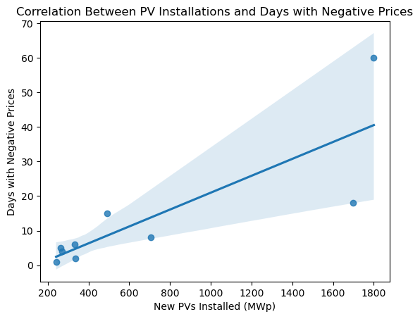

```python
# Plotting with trend line
sns.regplot(x='New_PVs_MWp', y='Negative_Price_Days', data=pv_price_days_without_2022)
plt.title('Correlation Between PV Installations and Days with Negative Prices')
plt.xlabel('New PVs Installed (MWp)')
plt.ylabel('Days with Negative Prices')
plt.show()
```

### When negative price occurrences happen?

```python
# Adding a column to specify days of the week
negative_price_data['Day_of_Week'] = negative_price_data['Date'].dt.day_name()
# Adding a column for the hour
negative_price_data['Hour'] = negative_price_data['Date'].dt.hour
```

```python
# Counting the number grouped by hour
negative_by_hour = negative_price_data.groupby('Hour').size().reset_index(name='NP Count')
```

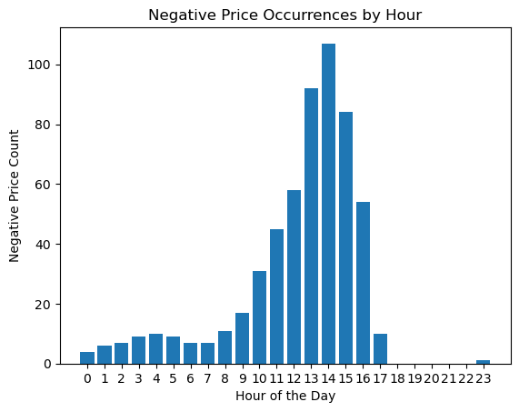

```python
# Plotting the count by hour
plt.bar(negative_by_hour['Hour'], negative_by_hour['NP Count'])
plt.title('Negative Price Occurrences by Hour')
plt.xlabel('Hour of the Day')
plt.ylabel('Negative Price Count')
plt.xticks(range(0, 24))
plt.show()
```

The plot below reveals that negative price occurrences often happen around 2pm.

```python
# Counting the number grouped by day of the week
negative_by_day = negative_price_data.groupby('Day_of_Week').size().reset_index(name='NP Count')

# Defining the order of the days
day_order = ['Monday', 'Tuesday', 'Wednesday', 'Thursday', 'Friday', 'Saturday', 'Sunday']
negative_by_day['Day_of_Week'] = pd.Categorical(negative_by_day['Day_of_Week'], categories=day_order)
negative_by_day = negative_by_day.sort_values('Day_of_Week')
```

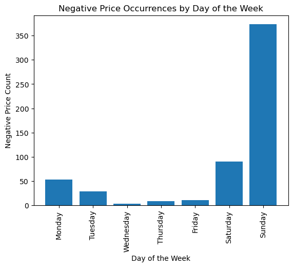

```python
# Plotting grouped by day of the week
plt.bar(negative_by_day['Day_of_Week'], negative_by_day['NP Count'])
plt.title('Negative Price Occurrences by Day of the Week')
plt.xlabel('Day of the Week')
plt.ylabel('Negative Price Count')
plt.xticks(rotation=90)
plt.show()
```

Negative price occurrences are more frequent over the weekends, with some also observed on Mondays.

### Which hour and day have the highest or lowest prices?

```python
# Adding a column to specify days of the week
price_data['Day_of_Week'] = price_data['Date'].dt.day_name()
# Adding a column for the hour
price_data['Hour'] = price_data['Date'].dt.hour
```

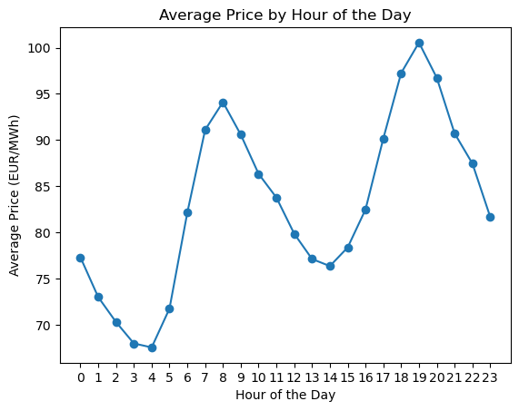

```python
# Calculating average price grouped by hour
grouped_by_hour = price_data.groupby('Hour')['Day Ahead Auction (CH)'].mean().reset_index()

plt.plot(grouped_by_hour['Hour'], grouped_by_hour['Day Ahead Auction (CH)'], marker='o')
plt.title('Average Price by Hour of the Day')
plt.xlabel('Hour of the Day')
plt.ylabel('Average Price (EUR/MWh)')
plt.xticks(range(0, 24))
plt.show()
```

Two peaks in price patterns are observed: lower prices around 4 am and 2 pm, and higher prices around 8 am and 7 pm.

```python
# Calculating average price grouped by day of the week
grouped_by_day = price_data.groupby('Day_of_Week')['Day Ahead Auction (CH)'].mean().reset_index()
grouped_by_day['Day_of_Week'] = pd.Categorical(grouped_by_day['Day_of_Week'], categories=day_order)
grouped_by_day = grouped_by_day.sort_values('Day_of_Week')
```

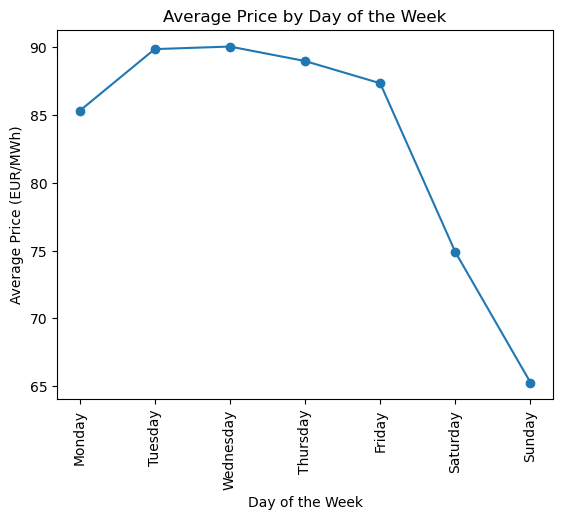

```python
# Plotting
plt.plot(grouped_by_day['Day_of_Week'], grouped_by_day['Day Ahead Auction (CH)'], marker='o')
plt.title('Average Price by Day of the Week')
plt.xlabel('Day of the Week')
plt.ylabel('Average Price (EUR/MWh)')
plt.xticks(rotation=90)
plt.show()
```

```python
# Grouping by hour and day of the week to get the average price for each hour of each day
grouped_by_day_hour = price_data.groupby(['Day_of_Week', 'Hour'])['Day Ahead Auction (CH)'].mean().reset_index()
grouped_by_day_hour['Day_of_Week'] = pd.Categorical(grouped_by_day_hour['Day_of_Week'], categories=day_order)
grouped_by_day_hour = grouped_by_day_hour.sort_values(['Day_of_Week', 'Hour'])
```

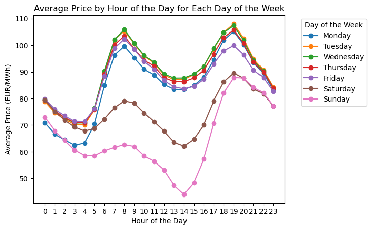

```python
# Plotting hourly patterns for each day of the week separately
for day in day_order:
    weekly_data = grouped_by_day_hour[grouped_by_day_hour['Day_of_Week'] == day]
    plt.plot(weekly_data['Hour'], weekly_data['Day Ahead Auction (CH)'], marker='o', label=day)

plt.title('Average Price by Hour of the Day for Each Day of the Week')
plt.xlabel('Hour of the Day')
plt.ylabel('Average Price (EUR/MWh)')
plt.xticks(range(0, 24))
plt.legend(title='Day of the Week', bbox_to_anchor=(1.05, 1))
plt.show()
```

While prices tend to be lower during weekends, the observed patterns remain similar with two peaks of high and low prices.

### What are the average negative prices per year?

```python
# Calculating the average negative price per year
average_negative_price = negative_price_data.groupby('Year')['Day Ahead Auction (CH)'].mean().reset_index(name='Average_Negative_Price')
print(average_negative_price)
```

```
   Year  Average_Negative_Price
0  2015               -6.776667
1  2016              -14.790417
2  2017              -34.190000
3  2018              -11.089310
4  2019              -13.881176
5  2020              -13.456267
6  2021              -19.899268
7  2022               -1.000000
8  2023              -18.701579
9  2024              -18.597500
```

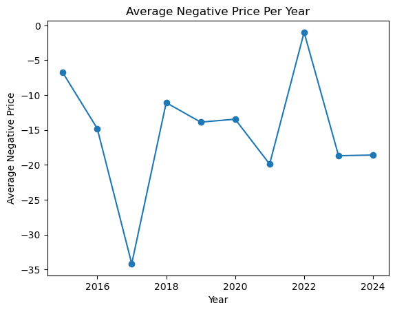

```python
# Plotting the average negative price per year
plt.plot(average_negative_price['Year'], average_negative_price['Average_Negative_Price'], marker='o')
plt.title('Average Negative Price Per Year')
plt.xlabel('Year')
plt.ylabel('Average Negative Price')
plt.show()
```

```python
# Calculating the overall average of 'Day Ahead Auction (CH)' excluding 2022 for further analysis
negative_price_data_without_2022 = negative_price_data[negative_price_data['Year'] != 2022]
overall_average_without_2022 = negative_price_data_without_2022['Day Ahead Auction (CH)'].mean()
average_without_2022_kwh = overall_average_without_2022 / 1000
```

### What are the yearly average prices for 19h (typically the highest price throughout the day)?

```python
# Calculating the average price at 19:00 for each year
price_data['Hour'] = price_data['Date'].dt.hour
average_price_19h = price_data[price_data['Hour'] == 19].groupby('Year')['Day Ahead Auction (CH)'].mean().reset_index(name='Avg_Price_19h')
print(average_price_19h)
```

```
   Year  Avg_Price_19h
0  2015      48.823479
1  2016      45.680902
2  2017      54.682274
3  2018      61.289260
4  2019      48.168027
5  2020      42.760464
6  2021     136.772658
7  2022     336.295123
8  2023     133.034521
9  2024      98.350710
```

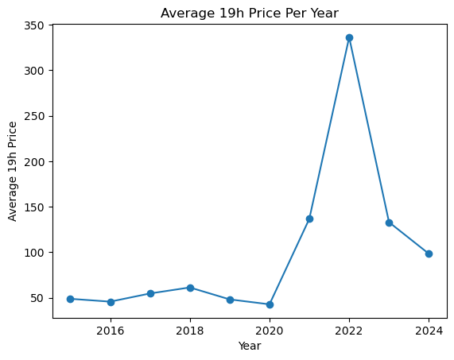

```python
# Plotting the average negative price per year
plt.plot(average_price_19h['Year'], average_price_19h['Avg_Price_19h'], marker='o')
plt.title('Average 19h Price Per Year')
plt.xlabel('Year')
plt.ylabel('Average 19h Price')
plt.show()
```

From the plot, it is evident that prices in 2022 were significantly higher compared to other years. This helps explain why the number of negative price occurrences was notably low in 2022.

## Simulations

### Calculating potential profit based on the 2023 and 2024 data

The following scenarios have been tested.

- Scenario 1: Buy at 0 or below and sell from 19h (typically the highest price)
- Scenario 2: Buy at two low peaks and sell at two high peaks
- Scenario 3: Buy at two low peaks and sell at two high peaks from March to October
- Scenario 4: Buy at bottom 40% prices and sell at top 40% prices
- Scenario 5: Buy at bottom 25% prices and sell at top 25% prices¶

```python
# Setting up parameters (to be updated: Currently Tesla model 3 data is applied)
storage_capacity = 82  # kWh
charge_discharge_rate = 15  # kWh
usable_capacity_rate = 0.7 # As per our discussion
efficiency = 0.9
```

```python
# Setting 'Date' as index for time series
price_data.set_index('Date', inplace=True)

# Converting prices from EUR/MWh to EUR/kWh
price_data['Price_kWh'] = price_data['Day Ahead Auction (CH)'] / 1000

# Extracting yearly data
price_data_2023 = price_data[price_data.index.year == 2023]
price_data_2024 = price_data[price_data.index.year == 2024]
```

#### Scenario 1: Buy at 0 or below and sell from 19h (typically the highest price)

```python
def simulate_scenario_1(price_data, price_column, storage_capacity, charge_discharge_rate, usable_capacity_rate, efficiency, time_interval='1h'):
    state_of_charge = 0  # kWh
    profit = 0  # EUR
    cost = 0  # EUR
    usable_capacity = storage_capacity * usable_capacity_rate

    # Adjust charge_discharge_rate for 15-minute intervals
    if time_interval == '15min':
        energy_per_interval = charge_discharge_rate / 4  # 15-minute intervals
    else:
        energy_per_interval = charge_discharge_rate

    for timestamp, price in price_data[price_column].items():
        # Buy when price is 0 or below
        if price <= 0 and state_of_charge < usable_capacity:
            energy_to_buy = min(energy_per_interval, usable_capacity - state_of_charge)
            cost += energy_to_buy * price
            state_of_charge += energy_to_buy

        # Sell from 19h
        elif 19 <= timestamp.hour and state_of_charge > 0:
            energy_to_sell = min(energy_per_interval, state_of_charge)
            revenue = energy_to_sell * efficiency * price
            state_of_charge -= energy_to_sell
            profit += revenue

    return profit - cost
```

#### Scenario 2: Buy at two low peaks and sell at two high peaks

```python
def simulate_scenario_2(price_data, price_column, storage_capacity, charge_discharge_rate, usable_capacity_rate, efficiency, time_interval='1h'):
    state_of_charge = 0  # kWh
    profit = 0  # EUR
    cost = 0  # EUR
    usable_capacity = storage_capacity * usable_capacity_rate

    # Adjust charge_discharge_rate for 15-minute intervals
    if time_interval == '15min':
        energy_per_interval = charge_discharge_rate / 4
    else:
        energy_per_interval = charge_discharge_rate

    for timestamp, price in price_data[price_column].items():
        hour = timestamp.hour

        # Buy at 2–5 AM or 1–3 PM
        if (2 <= hour <= 5 or 13 <= hour <= 15) and state_of_charge < usable_capacity:
            energy_to_buy = min(energy_per_interval, usable_capacity - state_of_charge)
            cost += energy_to_buy * price
            state_of_charge += energy_to_buy

        # Sell at 7–10 AM or 6–8 PM
        elif (7 <= hour <= 10 or 18 <= hour <= 20) and state_of_charge > 0:
            energy_to_sell = min(energy_per_interval, state_of_charge)
            revenue = energy_to_sell * efficiency * price
            state_of_charge -= energy_to_sell
            profit += revenue

    return profit - cost
```

#### Scenario 3: Buy at two low peaks and sell at two high peaks from March to October

```python
def simulate_scenario_3(price_data, price_column, storage_capacity, charge_discharge_rate, usable_capacity_rate, efficiency, time_interval='1h'):
    state_of_charge = 0  # kWh
    profit = 0  # EUR
    cost = 0  # EUR
    usable_capacity = storage_capacity * usable_capacity_rate

    # Adjust charge_discharge_rate for 15-minute intervals
    if time_interval == '15min':
        energy_per_interval = charge_discharge_rate / 4
    else:
        energy_per_interval = charge_discharge_rate

    for timestamp, price in price_data[price_column].items():
        month = timestamp.month
        hour = timestamp.hour

        # Only if the date is between March and October
        if 3 <= month <= 10:
            # Buy at 2–5 AM or 1–3 PM
            if (2 <= hour <= 5 or 13 <= hour <= 15) and state_of_charge < usable_capacity:
                energy_to_buy = min(energy_per_interval, usable_capacity - state_of_charge)
                cost += energy_to_buy * price
                state_of_charge += energy_to_buy

            # Sell at 7–10 AM or 6–8 PM
            elif (7 <= hour <= 10 or 18 <= hour <= 20) and state_of_charge > 0:
                energy_to_sell = min(energy_per_interval, state_of_charge)
                revenue = energy_to_sell * efficiency * price
                state_of_charge -= energy_to_sell
                profit += revenue

    return profit - cost
```

#### Scenario 4: Buy at bottom 40% prices and sell at top 40% prices

```python
def simulate_scenario_4(price_data, price_column, storage_capacity, charge_discharge_rate, usable_capacity_rate, efficiency, time_interval='1h'):
    state_of_charge = 0  # kWh
    profit = 0  # EUR
    cost = 0  # EUR
    usable_capacity = storage_capacity * usable_capacity_rate

    # Adjust charge_discharge_rate for 15-minute intervals
    if time_interval == '15min':
        energy_per_interval = charge_discharge_rate / 4
    else:
        energy_per_interval = charge_discharge_rate

    # 40% and 60% thresholds for prices
    low_price_threshold_s4 = price_data[price_column].quantile(0.4)
    high_price_threshold_s4 = price_data[price_column].quantile(0.6)

    for timestamp, price in price_data[price_column].items():
        # Buy when price is at or below the 40th percentile and storage is not full
        if price <= low_price_threshold_s4 and state_of_charge < usable_capacity:
            energy_to_buy = min(energy_per_interval, usable_capacity - state_of_charge)
            cost += energy_to_buy * price
            state_of_charge += energy_to_buy

        # Sell when price is at or above the 60th percentile and storage is not empty
        elif price >= high_price_threshold_s4 and state_of_charge > 0:
            energy_to_sell = min(energy_per_interval, state_of_charge)
            revenue = energy_to_sell * efficiency * price
            state_of_charge -= energy_to_sell
            profit += revenue

    return profit - cost
```

#### Scenario 5: Buy at bottom 25% prices and sell at top 25% prices

```python
def simulate_scenario_5(price_data, price_column, storage_capacity, charge_discharge_rate, usable_capacity_rate, efficiency, time_interval='1h'):
    state_of_charge = 0  # kWh
    profit = 0  # EUR
    cost = 0  # EUR
    usable_capacity = storage_capacity * usable_capacity_rate

    # Adjust charge_discharge_rate for 15-minute intervals
    if time_interval == '15min':
        energy_per_interval = charge_discharge_rate / 4
    else:
        energy_per_interval = charge_discharge_rate

    # 25% and 75% thresholds for prices
    low_price_threshold_s5 = price_data[price_column].quantile(0.25)
    high_price_threshold_s5 = price_data[price_column].quantile(0.75)

    for timestamp, price in price_data[price_column].items():
        # Buy when price is at or below the 25th percentile and storage is not full
        if price <= low_price_threshold_s5 and state_of_charge < usable_capacity:
            energy_to_buy = min(energy_per_interval, usable_capacity - state_of_charge)
            cost += energy_to_buy * price
            state_of_charge += energy_to_buy

        # Sell when price is at or above the 75th percentile and storage is not empty
        elif price >= high_price_threshold_s5 and state_of_charge > 0:
            energy_to_sell = min(energy_per_interval, state_of_charge)
            revenue = energy_to_sell * efficiency * price
            state_of_charge -= energy_to_sell
            profit += revenue

    return profit - cost
```

### Results

```python
# Simulating for 2023
profit_2023_s1 = simulate_scenario_1(price_data_2023, 'Price_kWh', storage_capacity, charge_discharge_rate, usable_capacity_rate, efficiency, time_interval='1h')
profit_2023_s2 = simulate_scenario_2(price_data_2023, 'Price_kWh', storage_capacity, charge_discharge_rate, usable_capacity_rate, efficiency, time_interval='1h')
profit_2023_s3 = simulate_scenario_3(price_data_2023, 'Price_kWh', storage_capacity, charge_discharge_rate, usable_capacity_rate, efficiency, time_interval='1h')
profit_2023_s4 = simulate_scenario_4(price_data_2023, 'Price_kWh', storage_capacity, charge_discharge_rate, usable_capacity_rate, efficiency, time_interval='1h')
profit_2023_s5 = simulate_scenario_5(price_data_2023, 'Price_kWh', storage_capacity, charge_discharge_rate, usable_capacity_rate, efficiency, time_interval='1h')

# Simulating for 2024
profit_2024_s1 = simulate_scenario_1(price_data_2024, 'Price_kWh', storage_capacity, charge_discharge_rate, usable_capacity_rate, efficiency, time_interval='1h')
profit_2024_s2 = simulate_scenario_2(price_data_2024, 'Price_kWh', storage_capacity, charge_discharge_rate, usable_capacity_rate, efficiency, time_interval='1h')
profit_2024_s3 = simulate_scenario_3(price_data_2024, 'Price_kWh', storage_capacity, charge_discharge_rate, usable_capacity_rate, efficiency, time_interval='1h')
profit_2024_s4 = simulate_scenario_4(price_data_2024, 'Price_kWh', storage_capacity, charge_discharge_rate, usable_capacity_rate, efficiency, time_interval='1h')
profit_2024_s5 = simulate_scenario_5(price_data_2024, 'Price_kWh', storage_capacity, charge_discharge_rate, usable_capacity_rate, efficiency, time_interval='1h')

print("Profit for 2023")
print(f"Scenario 1: {profit_2023_s1:.2f} EUR")
print(f"Scenario 2: {profit_2023_s2:.2f} EUR")
print(f"Scenario 3: {profit_2023_s3:.2f} EUR")
print(f"Scenario 4: {profit_2023_s4:.2f} EUR")
print(f"Scenario 5: {profit_2023_s5:.2f} EUR\n")
print("Profit for 2024")
print(f"Scenario 1: {profit_2024_s1:.2f} EUR")
print(f"Scenario 2: {profit_2024_s2:.2f} EUR")
print(f"Scenario 3: {profit_2024_s3:.2f} EUR")
print(f"Scenario 4: {profit_2024_s4:.2f} EUR")
print(f"Scenario 5: {profit_2024_s5:.2f} EUR")
```

```
Profit for 2023
Scenario 1: 64.59 EUR
Scenario 2: 622.15 EUR
Scenario 3: 456.61 EUR
Scenario 4: 209.72 EUR
Scenario 5: 128.43 EUR

Profit for 2024
Scenario 1: 216.39 EUR
Scenario 2: 576.98 EUR
Scenario 3: 470.61 EUR
Scenario 4: 236.55 EUR
Scenario 5: 194.85 EUR
```

There must be room for improvement, but with the initial cost of the battery (in the case of Tesla, over 10000 EUR), the annual profit from energy trading seems insufficient to cover the costs in the short term.

## Groupe E

Groupe E is one of the pioneer suppliers offering dynamic pricing in Switzerland. To estimate the potential profit for captive customers in the region, the same simulation models have been applied to their historical pricing data.

```python
vario_data = pd.read_csv("tariff_data_2021_to_2024.csv")

missing_vario = vario_data.isnull().sum()
print(missing_vario)
```

```
start_timestamp    0
end_timestamp      0
vario_plus         0
vario_grid         0
dt_plus            0
unit               0
dtype: int64
```

```python
# Converting start_timestamp to datetime with UTC
vario_data['start_timestamp'] = pd.to_datetime(vario_data['start_timestamp'], errors='coerce', utc=True)
vario_data['end_timestamp'] = pd.to_datetime(vario_data['end_timestamp'], errors='coerce', utc=True)

# Converting to CET
vario_data['start_timestamp'] = vario_data['start_timestamp'].dt.tz_convert('Europe/Zurich')
vario_data['end_timestamp'] = vario_data['end_timestamp'].dt.tz_convert('Europe/Zurich')

print(vario_data.dtypes)
vario_data.head()
```

```
start_timestamp    datetime64[ns, Europe/Zurich]
end_timestamp      datetime64[ns, Europe/Zurich]
vario_plus                               float64
vario_grid                               float64
dt_plus                                  float64
unit                                      object
dtype: object
```

|  | start_timestamp | end_timestamp | vario_plus | vario_grid | dt_plus | unit |
| --- | --- | --- | --- | --- | --- | --- |
| 0 | 2021-01-01 00:00:00+01:00 | 2021-01-01 00:15:00+01:00 | 30.02 | 7.32 | 25.08 | Rp./kWh |
| 1 | 2021-01-01 00:15:00+01:00 | 2021-01-01 00:30:00+01:00 | 30.12 | 7.41 | 25.08 | Rp./kWh |
| 2 | 2021-01-01 00:30:00+01:00 | 2021-01-01 00:45:00+01:00 | 28.43 | 5.85 | 25.08 | Rp./kWh |
| 3 | 2021-01-01 00:45:00+01:00 | 2021-01-01 01:00:00+01:00 | 26.78 | 4.33 | 25.08 | Rp./kWh |
| 4 | 2021-01-01 01:00:00+01:00 | 2021-01-01 01:15:00+01:00 | 34.81 | 11.75 | 25.08 | Rp./kWh |

```python
vario_data['Year'] = vario_data['start_timestamp'].dt.year
```

```python
# Setting 'Date' as index for time series
vario_data.set_index('start_timestamp', inplace=True)

# Converting into CHF/kwh from Rp./kwh
vario_data['vario_plus_chf'] = vario_data['vario_plus']/100
vario_data['vario_grid_chf'] = vario_data['vario_grid']/100

# Extracting yearly data
vario_2023 = vario_data[vario_data.index.year == 2023]
vario_2024 = vario_data[vario_data.index.year == 2024]
```

```python
# Simulating for 2023
profit_vario_2023_s1 = simulate_scenario_1(vario_2023, 'vario_plus_chf', storage_capacity, charge_discharge_rate, usable_capacity_rate, efficiency, time_interval='15min')
profit_vario_2023_s2 = simulate_scenario_2(vario_2023, 'vario_plus_chf', storage_capacity, charge_discharge_rate, usable_capacity_rate, efficiency, time_interval='15min')
profit_vario_2023_s3 = simulate_scenario_3(vario_2023, 'vario_plus_chf', storage_capacity, charge_discharge_rate, usable_capacity_rate, efficiency, time_interval='15min')
profit_vario_2023_s4 = simulate_scenario_4(vario_2023, 'vario_plus_chf', storage_capacity, charge_discharge_rate, usable_capacity_rate, efficiency, time_interval='15min')
profit_vario_2023_s5 = simulate_scenario_5(vario_2023, 'vario_plus_chf', storage_capacity, charge_discharge_rate, usable_capacity_rate, efficiency, time_interval='15min')

# Simulating for 2024
profit_vario_2024_s1 = simulate_scenario_1(vario_2024, 'vario_plus_chf', storage_capacity, charge_discharge_rate, usable_capacity_rate, efficiency, time_interval='15min')
profit_vario_2024_s2 = simulate_scenario_2(vario_2024, 'vario_plus_chf', storage_capacity, charge_discharge_rate, usable_capacity_rate, efficiency, time_interval='15min')
profit_vario_2024_s3 = simulate_scenario_3(vario_2024, 'vario_plus_chf', storage_capacity, charge_discharge_rate, usable_capacity_rate, efficiency, time_interval='15min')
profit_vario_2024_s4 = simulate_scenario_4(vario_2024, 'vario_plus_chf', storage_capacity, charge_discharge_rate, usable_capacity_rate, efficiency, time_interval='15min')
profit_vario_2024_s5 = simulate_scenario_5(vario_2024, 'vario_plus_chf', storage_capacity, charge_discharge_rate, usable_capacity_rate, efficiency, time_interval='15min')

print("Profit Vario for 2023")
print(f"Scenario 1: {profit_vario_2023_s1:.2f} CHF")
print(f"Scenario 2: {profit_vario_2023_s2:.2f} CHF")
print(f"Scenario 3: {profit_vario_2023_s3:.2f} CHF")
print(f"Scenario 4: {profit_vario_2023_s4:.2f} CHF")
print(f"Scenario 5: {profit_vario_2023_s5:.2f} CHF\n")
print("Profit Vario for 2024")
print(f"Scenario 1: {profit_vario_2024_s1:.2f} CHF")
print(f"Scenario 2: {profit_vario_2024_s2:.2f} CHF")
print(f"Scenario 3: {profit_vario_2024_s3:.2f} CHF")
print(f"Scenario 4: {profit_vario_2024_s4:.2f} CHF")
print(f"Scenario 5: {profit_vario_2024_s5:.2f} CHF")
```

```
Profit Vario for 2023
Scenario 1: 0.00 CHF
Scenario 2: 3500.53 CHF
Scenario 3: 2155.67 CHF
Scenario 4: 3552.75 CHF
Scenario 5: 3399.05 CHF

Profit Vario for 2024
Scenario 1: 0.00 CHF
Scenario 2: 3575.50 CHF
Scenario 3: 2108.33 CHF
Scenario 4: 3601.16 CHF
Scenario 5: 3367.24 CHF
```

The results indicate that higher profits are achievable using the dynamic prices offered by Groupe E. Scenario 1 remains unprofitable for both years, as no negative price is present. However, their prices higher than spot market make it more profitable, especially when the price gaps are larger.

## Predictions

#### Annual PV production including predictions from the official statistics

Source: https://www.swissolar.ch/02_markt-politik/solarmonitor-schweiz/solarmonitor_schweiz_2024_fr.pdf

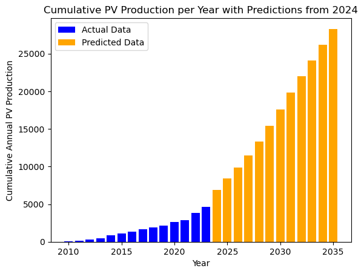

```python
# Plotting annual PV production with predictions from 2024
colors = ['blue' if year < 2024 else 'orange' for year in production_data['Year']]

plt.bar(production_data['Year'], production_data['PV Production (GWh)'], color=colors)
plt.title('Cumulative PV Production per Year with Predictions from 2024')
plt.xlabel('Year')
plt.ylabel('Cumulative Annual PV Production')
blue_patch = plt.Rectangle((0, 0), 1, 1, fc="blue", edgecolor='none')
orange_patch = plt.Rectangle((0, 0), 1, 1, fc="orange", edgecolor='none')
plt.legend([blue_patch, orange_patch], ['Actual Data', 'Predicted Data'])
plt.show()
```

```python
# Displaying the official predictions from 2024 onwards
production_data.sort_values(by="Year", ascending=True)
production_data_2024_onwards = production_data[production_data["Year"] >= 2024]
print(production_data_2024_onwards)
```

```
    Year  PV Production (GWh)  Annual Production Growth
0   2035                28300                  1.080153
1   2034                26200                  1.087137
2   2033                24100                  1.095455
3   2032                22000                  1.111111
4   2031                19800                  1.125000
5   2030                17600                  1.142857
6   2029                15400                  1.157895
7   2028                13300                  1.156522
8   2027                11500                  1.161616
9   2026                 9900                  1.178571
10  2025                 8400                  1.217391
11  2024                 6900                  1.492215
```

#### Applying a ML model to PV production data (log transformation and linear regression)

To compare the results, the log transformation and the linear regression model has been applied to the PV production data up to the year 2023.

```python
# Filtering data up to 2023
production_to_2023 = production_data[production_data['Year'] <= 2023].copy()

# Applying log transformation to PV Production
production_to_2023['Log_PV_Production'] = np.log(production_to_2023['PV Production (GWh)'])

X = production_to_2023['Year'].values.reshape(-1, 1)
y = production_to_2023['Log_PV_Production'].values

pv_model = LinearRegression()
pv_model.fit(X, y)

years = list(range(2024, 2036))
predicted_log_pv_production = []

for year in years:
    predicted_log_value = pv_model.predict([[year]])
    predicted_pv_production_value = np.exp(predicted_log_value[0])
    predicted_log_pv_production.append(predicted_pv_production_value)
    print(f"{year}: {predicted_pv_production_value:.2f} GWh")
```

```
2024: 8248.00 GWh
2025: 10821.60 GWh
2026: 14198.22 GWh
2027: 18628.43 GWh
2028: 24440.99 GWh
2029: 32067.22 GWh
2030: 42073.03 GWh
2031: 55200.92 GWh
2032: 72425.05 GWh
2033: 95023.56 GWh
2034: 124673.39 GWh
2035: 163574.75 GWh
```

After applying the log transformation, the predicted values turned out to be greater than the official statistics. Given that the official statistics already appear optimistic, we will proceed with these official figures for further analyses.

#### Applying a ML model to negative price data based on production predictions (simple linear regression)

```python
# Extracting the production data up to 2024
production_to_2024 = production_data[production_data['Year'] <= 2024]

# Joining the production and negative price data
production_negative = pd.merge(production_to_2024, negative_price_days, on='Year', how='inner')
# Excluding the data for 2022
production_negative = production_negative[production_negative['Year'] != 2022]

X = production_negative['PV Production (GWh)'].values.reshape(-1, 1)
y = production_negative['Negative_Price_Days'].values

price_model = LinearRegression()
price_model.fit(X, y)

years = list(range(2025, 2036))
predicted_negative_days = []

for year in years:
    pv_production = production_data.loc[production_data['Year'] == year, 'PV Production (GWh)'].values[0]
    predicted_negative_days_value = price_model.predict([[pv_production]])
    predicted_negative_days.append(predicted_negative_days_value[0])
    print(f"{year}: {predicted_negative_days_value[0]:.2f}")
```

```
2025: 65.47
2026: 79.47
2027: 94.40
2028: 111.20
2029: 130.80
2030: 151.33
2031: 171.87
2032: 192.40
2033: 212.00
2034: 231.60
2035: 251.20
```

```python
r2score = price_model.score(X, y)
print(f"R² Score: {r2score:.2f}")
```

```
R² Score: 0.88
```

#### Applying a ML model to negative price data based on production predictions (log transformation and linear regression)

```python
# Applying log transformation to the data
X_log = np.log(production_negative['PV Production (GWh)'].values).reshape(-1, 1)
y_log = np.log(production_negative['Negative_Price_Days'].values)

price_model_log = LinearRegression()
price_model_log.fit(X_log, y_log)

years = list(range(2025, 2036))
predicted_negative_days = []

for year in years:
    pv_production = production_data.loc[production_data['Year'] == year, 'PV Production (GWh)'].values[0]
    log_pv_production = np.log(pv_production)
    predicted_log_negative_days = price_model_log.predict([[log_pv_production]])
    predicted_negative_days_value = np.exp(predicted_log_negative_days[0])

    predicted_negative_days.append(predicted_negative_days_value)
    print(f"{year}: {predicted_negative_days_value:.2f}")
```

```
2025: 68.98
2026: 93.33
2027: 122.97
2028: 160.71
2029: 210.50
2030: 269.15
2031: 334.32
2032: 405.87
2033: 480.03
2034: 559.83
2035: 645.20
```

```python
r2score_log = price_model_log.score(X_log, y_log)
print(f"R² Score: {r2score_log:.2f}")
```

```
R² Score: 0.76
```

#### Simulating the potential profit based on 2024 data

```python
# For reproducibility
np.random.seed(0)

# Current number of negative price days in 2024
negative_price_days_2024 = negative_price_days.loc[negative_price_days['Year'] == 2024, 'Negative_Price_Days'].values[0]

# Calculating the extra negative price days based on 2024 data
for year in range(2025, 2031):
    predicted_negative_days_year = predicted_negative_days[year - 2025]
    extra_negative_price_days_year = int(predicted_negative_days_year - negative_price_days_2024)

    if extra_negative_price_days_year > 0:
        price_data_year = price_data_2024.copy()
        price_data_year['Date_only'] = price_data_year.index.date  # only date

        # Extracting non-negative price days (where Price_kWh >= 0) from the data
        non_negative_days = price_data_year[price_data_year['Price_kWh'] >= 0]['Date_only'].unique()

        # Checking if there are enough non-negative days to add the extra negative price days
        if len(non_negative_days) >= extra_negative_price_days_year:
            # Randomly selecting the extra days to apply negative prices
            selected_days = np.random.choice(non_negative_days, size=extra_negative_price_days_year, replace=False)

            for day in selected_days:
                # Selecting random hours for the chosen day to apply the negative price
                day_indices = price_data_year[price_data_year['Date_only'] == day].index
                selected_hour = np.random.choice(day_indices)

                # Applying the negative price for the selected hour
                price_data_year.loc[selected_hour, 'Price_kWh'] = average_without_2022_kwh

            print(f"Adjusted price for {extra_negative_price_days_year} days")
        else:
            print(f"Not enough non-negative days to apply extra negative price days for {year}.")

    # Simulating profits for the year with the adjusted price data
    profit_year_s1 = simulate_scenario_1(price_data_year, 'Price_kWh', storage_capacity, charge_discharge_rate, usable_capacity_rate, efficiency, time_interval='1h')
    profit_year_s2 = simulate_scenario_2(price_data_year, 'Price_kWh', storage_capacity, charge_discharge_rate, usable_capacity_rate, efficiency, time_interval='1h')
    profit_year_s3 = simulate_scenario_3(price_data_year, 'Price_kWh', storage_capacity, charge_discharge_rate, usable_capacity_rate, efficiency, time_interval='1h')
    profit_year_s4 = simulate_scenario_4(price_data_year, 'Price_kWh', storage_capacity, charge_discharge_rate, usable_capacity_rate, efficiency, time_interval='1h')
    profit_year_s5 = simulate_scenario_5(price_data_year, 'Price_kWh', storage_capacity, charge_discharge_rate, usable_capacity_rate, efficiency, time_interval='1h')

    print(f"Profit for {year}")
    print(f"Scenario 1: {profit_year_s1:.2f} EUR")
    print(f"Scenario 2: {profit_year_s2:.2f} EUR")
    print(f"Scenario 3: {profit_year_s3:.2f} EUR")
    print(f"Scenario 4: {profit_year_s4:.2f} EUR")
    print(f"Scenario 5: {profit_year_s5:.2f} EUR\n")
```

```
Adjusted price for 8 days
Profit for 2025
Scenario 1: 232.27 EUR
Scenario 2: 572.35 EUR
Scenario 3: 469.43 EUR
Scenario 4: 246.94 EUR
Scenario 5: 205.69 EUR

Adjusted price for 33 days
Profit for 2026
Scenario 1: 267.88 EUR
Scenario 2: 578.13 EUR
Scenario 3: 470.08 EUR
Scenario 4: 271.66 EUR
Scenario 5: 230.34 EUR

Adjusted price for 62 days
Profit for 2027
Scenario 1: 301.41 EUR
Scenario 2: 578.98 EUR
Scenario 3: 474.57 EUR
Scenario 4: 298.92 EUR
Scenario 5: 253.43 EUR

Adjusted price for 100 days
Profit for 2028
Scenario 1: 368.60 EUR
Scenario 2: 553.88 EUR
Scenario 3: 460.38 EUR
Scenario 4: 347.46 EUR
Scenario 5: 304.41 EUR

Adjusted price for 150 days
Profit for 2029
Scenario 1: 434.14 EUR
Scenario 2: 562.53 EUR
Scenario 3: 462.75 EUR
Scenario 4: 363.27 EUR
Scenario 5: 315.16 EUR

Adjusted price for 209 days
Profit for 2030
Scenario 1: 509.84 EUR
Scenario 2: 550.14 EUR
Scenario 3: 457.64 EUR
Scenario 4: 430.67 EUR
Scenario 5: 372.75 EUR
```

```python
ofen_pv_data = pd.read_csv("ElectricityProductionPlant.csv")
```

## Conclusion

This report has analyzed trends, patterns and relationships of PV installations and electricity prices in Switzerland and assessed the potential profitability of energy storage systems using machine learning approaches.

#### Key takeaways:

- Trends: There is a strong positive correlation between the number of PV installations and negative electricity prices. Negative price occurrences are more frequent over weekends and Mondays, and they typically happen around 2 pm. Finally, electricity prices generally follow a two-peak pattern throughout the day, with lower prices around 4 am and 2 pm, and higher prices around 8 am and 7 pm. Prices tend to be lower on weekends compared to weekdays.
- Profitability of Energy Storage: The report has simulated various scenarios for using an energy storage system to exploit price fluctuations. While some scenarios show potential profit, the initial cost of the battery might outweigh the short-term gains from energy trading on the spot market. However, the results with Groupe E’s dynamic prices reveal that decent profits are possible, potentially covering costs as they are higher than the spot market.
- Need for Further Analysis: The report acknowledges that there is room for improvement in the analysis. Factors like the initial battery cost, lifespan and network fees need to be considered for a more comprehensive assessment.